# Procedimento para checagem e atualização da base geoespacial das escolas (2022 a 2025)

Author

CEM-USP (Thiago C. Jacovine, Kaue O. Almeida)

Published

April 29, 2026

Modified

August 31, 2026

## Visão geral

O presente documento disponibiliza o procedimento para a definição, a manutenção e a atualização dos dados geoespaciais das escolas brasileiras presentes na plataforma [GeoReDUS](https://www.redus.org.br/georedus?v=v0). O **objetivo** é obter uma **base geoespacial única das escolas ao longo do tempo**. Para isso, propõe-se um procedimento de compatibilização espaço-temporal dos dados.

A proposta, como pode ser vista neste documento e no sumário localizado no canto superior direito da página, está estruturada em “grandes etapas”. São elas: i) preparação do ambiente local para armazenamento dos dados originais (microdados do [censo escolar](https://www.gov.br/inep/pt-br/areas-de-atuacao/pesquisas-estatisticas-e-indicadores/censo-escolar) e [catálogo de escolas](https://www.gov.br/inep/pt-br/acesso-a-informacao/dados-abertos/inep-data/catalogo-de-escolas)); ii) acesso, importação e definição das operações relacionadas à limpeza e à organização da base compatibilizada dos microdados escolares; iii) breve exploração e análise dos dados; iv) geocodificação das escolas que não apresentam coordenadas geográficas e v) exportação dos resultados gerados.

## Preparação e configurações iniciais

O primeiro passo para a geração dos dados geoespaciais das escolas consiste na preparação e estruturação do [R](https://cran.r-project.org/) e do ambiente local onde os dados serão armazenados. Dessa forma, o procedimento poderá ser reproduzido por qualquer pessoa em qualquer local, obtendo-se os mesmos resultados.

### Carregando os pacotes necessários

De modo a facilitar algumas operações, e tomando como guia os princípios [FAIR](https://www.go-fair.org/fair-principles/) e do [Tidyverse](https://tidyverse.org/), alguns pacotes serão habilitados. Note: graças ao uso do [Renv](https://rstudio.github.io/renv/), as mesmas versões dos pacotes utilizadas no momento de geração dos dados serão replicadas em seu ambiente local.

```r
# Defina quais serão as versões dos pacotes utilizadas (mesmas versões do presente documento)
renv::restore()

# Carregue os pacotes que serão utilizados
library(archive)
library(arrow)
library(fs)
library(geocodebr)
library(gt)
library(httr2)
library(here)
library(janitor)
library(knitr)
library(readxl)
library(quarto)
library(scales)
library(sf)
library(tidyverse)
library(zip)
library(curl)
library(sfarrow)
```

### Definindo algumas variáveis para fins de reprodutibilidade/atualizações

Para facilitar possíveis alterações, atualizações, usos recorrentes e/ou novas consultas, algumas variáveis já serão definidas neste momento. Por ora, elas compreendem o *total dos censos escolares analisados* (`censo_esc_tot`) e os seus respectivos *anos* (`censo_esc_anos`).

```r
# Defina o número de bases analisadas (neste momento, quatro: 2022, 2023, 2024 e 2025)
censo_esc_anos <- c(2022, 2023, 2024, 2025)
censo_esc_tot <- length(censo_esc_anos)
```

## Obtenção, transformação e organização dos dados

A partir deste momento, serão realizadas algumas operações voltadas à obtenção, ao tratamento e à organização dos dados que serão utilizados para gerar a base geoespacial das escolas brasileiras ao longo do tempo.

### Criando a estrutura de armazenamento do ambiente local

Para armazenar os dados, três pastas serão criadas:

- `01_logs`: local destinado ao armazenamento dos registros de operações e modificações realizadas;
- `02_originais`: local destinado ao armazenamento dos dados originais, e,
- `03_processados`: local destinado ao armazenamento dos dados gerados por meio do atual procedimento.

```r
# Crie os caminhos das pastas que armazenarão os dados
pastas <- c(
    here("dados", str_c("01", "_logs")),
    here("dados", str_c("02", "_originais")),
    here("dados", str_c("03", "_processados"))
)

# Crie as pastas, caso não existam
walk(pastas, ~ if(!dir_exists(.x)) dir_create(.x, recurse = TRUE))

# Armazene o caminho de algumas pastas em objetos para facilitar as chamadas ao longo do código
pasta_logs <- pastas[1]
pasta_dados_originais <- pastas[2]
pasta_dados_processados <- pastas[3]
```

### Criando o procedimento para a obtenção, o tratamento e a organização dos dados

A obtenção, o tratamento e a organização dos microdados dos censos escolares ao longo do tempo podem ser realizadas de diferentes formas. No presente caso, optou-se por criar uma função que reúne as etapas necessárias para essas ações.

Por meio dela, os dados originais serão:

- Acessados via internet, baixados para o ambiente local (computador) e importados para o R;
- Realizadas operações de tratamento (exclusão e geração de variáveis; transformação de classes, (re)organização dos dados, etc.)
- Geração de uma base única compatibilizada entre os anos analisados - base, essa, que servirá de insumo para a etapa de geocodificação, mais adiante.

```r
# Definição da função para processar os dados de cada ano
processar_censo_ano <- function(ano, max_tentativas = 3) {
  # Preparação dos registros das ações e alterações (logs)
  ## Especifique o caminho onde o arquivo de log será armazenado
  arquivo_log <- file.path(
    pasta_logs,
    str_glue("processamento_{ano}_{Sys.Date()}.log")
  )

  ## Crie uma função para gerar as mensagens de log
  log_msg <- function(msg, tipo = "INFO") {
    timestamp <- format(Sys.time(), "%Y-%m-%d %H:%M:%S")
    mensagem <- str_glue("[{timestamp}] [{tipo}] Ano {ano}: {msg}")
    write_lines(mensagem, arquivo_log, append = TRUE)
    message(mensagem)
  }

  # Acesso aos dados
  ## Gere uma mensagem indicando o início do processamento
  log_msg("Início do processamento")

  ## Defina o endereço para baixar o dado
  base_url <- "https://download.inep.gov.br"

  ## Defina o nome do arquivo a ser baixado
  arq_orig <- str_c(
    "microdados_censo_escolar_",
    ano,
    if_else(ano == 2025, "_", ""),
    ".zip"
  ) # O if_else é usado para contemplar a grafia diferente dos microdados de 2025 (um traço antes do ".zip")

  ## Baixe os dados
  for (tentativa in 1:max_tentativas) {
    # Gere uma mensagem sobre o início do processo
    log_msg(str_glue(
      "Tentativa de download/importação {tentativa}/{max_tentativas}"
    ))

    resultado <- tryCatch(
      {
        # Baixe o dado da fonte e salve-o localmente, caso ele ainda não exista
        if (!file.exists(file.path(pasta_dados_originais, arq_orig))) {
          url_completa <- paste0(base_url, "/dados_abertos/", arq_orig)

          destino <- file.path(pasta_dados_originais, arq_orig)

          # curl_download is specifically designed for downloading large files to disk
          curl_download(
            url = url_completa,
            destfile = destino,
            quiet = FALSE # Set to FALSE to see a progress bar in your console
          )
        }

        ## Renomeie a pasta original do dado de 2025, assumindo o mesmo padrão dos anos anteriores
        if (str_detect(arq_orig, "_\\.zip$")) {
          novo_nome <- str_replace(arq_orig, "_\\.zip$", ".zip")
          caminho_novo <- path(pasta_dados_originais, novo_nome)
          fs::file_move(
            file.path(pasta_dados_originais, arq_orig),
            caminho_novo
          )
        }

        ## Descompacte os dados
        ### Defina quais arquivos deverão ser descompactados
        arq_orig_zip <-
          pasta_dados_originais |>
          dir_ls(
            type = "file",
            regexp = str_c("microdados.*", ano, "\\.zip$"),
            ignore.case = TRUE
          )

        ### Descompacte os arquivos
        arq_orig_zip |>
          walk(
            \(x) {
              zip::unzip(
                x,
                exdir = pasta_dados_originais,
                overwrite = TRUE
              )
            },
            .progress = TRUE
          )

        ## Importe os dados para o ambiente do R

        ### Liste o nome do diretório desconsiderando os caracteres especiais
        caminho_original <- dir_ls(
          path = pasta_dados_originais,
          type = "directory",
          regexp = str_glue("Censo.*Escolar.*{ano}"),
          ignore.case = TRUE
        )

        # Altere o nome da pasta para o ano de 2022, adotando o mesmo padrão dos demais anos
        ## Defina o caminhho e o nome da nova pasta
        pasta_destino <- file.path(
          pasta_dados_originais,
          str_c("microdados_censo_escolar_", ano)
        )

        ## Cheque e, se for o caso, altere o nome da pasta antiga
        if (!dir_exists(pasta_destino)) {
          file_move(caminho_original, pasta_destino)
        }

        if (ano != 2025) {
          micro_base <- dir_ls(
            path = file.path(
              pasta_dados_originais,
              str_c("microdados_censo_escolar_", ano)
            ),
            recurse = TRUE,
            type = "file",
            # Garante que, excluído o caso de 2025, apenas os microdados serão registrados
            regexp = str_glue("microdados_ed_basica_{ano}\\.csv$")
          )
        } else {
          micro_base <- dir_ls(
            path = file.path(
              pasta_dados_originais,
              str_c("microdados_censo_escolar_", ano)
            ),
            recurse = TRUE,
            type = "file",
            glob = "*.csv"
          ) |>
            str_subset(
              pattern = "Curso_Tecnico_2025",
              negate = TRUE
            )
        }

        ### Crie uma mensagem indicando a ausência do arquivo, caso ele não seja encontrado
        if (length(micro_base) == 0) {
          stop("Arquivo CSV de microdados não encontrado")
        }

        ### Leia os dados brutos (microdados)
        if (ano != 2025) {
          micro_orig <- read_delim(
            micro_base,
            delim = ";",
            locale = locale(
              decimal_mark = ",",
              grouping_mark = ".",
              encoding = "latin1"
            ),
            col_types = cols(.default = col_character())
          ) |>
            clean_names() |>
            arrange(co_entidade)
        } else {
          micro_orig <- micro_base |>
            # Leia os dados de cada arquivo
            map(
              ~ read_csv2(
                .x,
                show_col_types = FALSE,
                locale = locale(encoding = "latin1"), # ISO-8859-1
                col_types = cols(.default = col_character())
              )
            ) |>
            # Junte todos os arquivos em uma base única
            reduce(full_join, by = c("CO_ENTIDADE", "NU_ANO_CENSO")) |>
            # Padronize a nomenclatura das variáveis
            janitor::clean_names() |>
            # Organize a base a partir do código das escolas
            arrange(co_entidade)
        }

        ### Crie uma mensagem indicando o número de linhas e colunas do dado bruto carregado (microdado)
        log_msg(str_glue(
          "Dados brutos carregados: {nrow(micro_orig)} linhas, {ncol(micro_orig)} colunas"
        ))

        # Transformação e organização dos dados
        microdados_esc_ativ <- micro_orig |>
          # Selecione as variáveis de interesse
          select(any_of(c(
            "nu_ano_censo",
            "sg_uf",
            "no_municipio",
            "co_municipio",
            "co_cep",
            "ds_endereco",
            "nu_endereco",
            "no_bairro",
            "no_entidade",
            "co_entidade",
            "tp_dependencia",
            "tp_situacao_funcionamento",
            "qt_mat_bas"
          ))) |>

          # Filtre apenas as escolas ativas (em funcionamento e com ao menos 1 matrícula)
          filter(
            tp_situacao_funcionamento == 1 &
              if_any(starts_with("qt_mat"), ~ . > 0)
          ) |>
          select(!tp_situacao_funcionamento) |>

          # Mude a classe de algumas variáveis
          mutate(
            # Substitua os valores 88888 por NA nas variáveis numéricas
            across(where(is.numeric), ~ na_if(., 88888)),

            # Recodifique a variável de tipo de dependência administrativa
            tp_dependencia = recode(
              tp_dependencia,
              "1" = "Federal",
              "2" = "Estadual",
              "3" = "Municipal",
              "4" = "Privada"
            )
          ) |>

          # Renomeie as variáveis para o padrão utilizado na plataforma GeoReDUS
          rename(
            ano_cn_escolar = nu_ano_censo,
            nm_mun = no_municipio,
            cd_mun = co_municipio,
            nm_escola = no_entidade,
            cod_escola = co_entidade,
            tp_dependencia = tp_dependencia
          )

        #Renomeia as variáveis de endereço para o padrão utilizado na plataforma GeoReDUS, exceto para o ano de 2025
        if (ano != 2025) {
          microdados_esc_ativ <- microdados_esc_ativ |>
            rename(
              cep = co_cep,
              endereco = ds_endereco,
              num_endereco = nu_endereco,
              nm_bairro = no_bairro
            )
        }

        ## Crie uma mensagem indicando o número de linhas e colunas do dado final gerado (microdados das escolas ativas)
        log_msg(str_glue(
          "Base final gerada: {nrow(microdados_esc_ativ)} escolas ativas, {ncol(microdados_esc_ativ)} variáveis"
        ))

        ## Crie uma mensagem explicitando os possíveis erros
        return(list(status = "sucesso", dados = microdados_esc_ativ))
      },
      error = function(e) {
        log_msg(str_glue("Erro: {e$message}"), "ERRO")

        if (tentativa < max_tentativas) {
          espera <- 2^tentativa
          log_msg(
            str_glue("Aguardando {espera}s antes da próxima tentativa"),
            "NOVA TENTATIVA"
          )
          Sys.sleep(espera)
        }
        return(list(status = "erro", mensagem = e$message))
      }
    )

    if (resultado$status == "sucesso") return(resultado$dados)
  }

  ## Crie uma mensagem sobre eventuais falhas definitivas
  log_msg("Falha após todas as tentativas", "FALHA")
  return(NULL)
}
```

### Implementando a função para o acesso e tratamento dos dados

Criada a função, basta aplicá-la ao conjunto de dados de interesse. O resultado esperado, neste caso, é a geração dos microdados das escolas ativas para cada um dos anos analisados.

**NoteLembrete**

*Escolas ativas* são aquelas que, de acordo com os dados do censo escolar, estão *em funcionamento* e apresentam *ao menos uma matrícula ativa*.

```r
# Implementação da leitura, tratamento e organização dos dados para cada censo
## Mensagem indicando o início do processamento dos dados de todos os anos
    message(strrep("=", 50))
    message("🚀 Processamento dos Censos Escolares")
    message(strrep("=", 50))

## Aplique a função de processamento para cada ano e armazene os resultados em uma lista
resultados <- censo_esc_anos |>
    set_names(str_c("microdados_esc_ativ_", censo_esc_anos)) |>
    map(processar_censo_ano)

## Salve os casos em que o processamento foi bem-sucedido e os casos em que houve falha
result_posit <- compact(resultados)

## Salve os casos em que houve falha
sel_falha <- map_lgl(resultados, is.null)
result_negat <- resultados[sel_falha]

## Crie uma base única com os dados dos censos
base_unic_cens_edu_orig <- result_posit |>
    map("dados") |>
    keep(is.data.frame) |>
    list_rbind()

## Gere um resumo sobre todo o procedimento ("Relatório final")
    message("\n", strrep("=", 50))
    message("📊 RESUMO:")
    message(str_glue("✅ Sucesso: {length(result_posit)} anos"))

if (length(result_posit) > 0) {
    iwalk(result_posit, ~ message(str_glue("   ├─ {.y}: {nrow(.x)} escolas, {ncol(.x)} variáveis")))
}

if (length(result_negat) > 0) {
    message(str_glue("❌ Falha: {length(result_negat)} anos"))
    iwalk(result_negat, ~ message(str_glue("   └─ {.y} (verifique os logs)")))
}
    message(strrep("=", 50))
```

## Explorando os dados dos Censos Escolares (2022, 2023, 2024, 2025)

### Mapeando as escolas ao longo dos anos

A partir da base única criada (`base_unic_cens_edu_orig`), torna-se possível identificar a presença de cada escola ao longo do tempo. Tomando como exemplo o caso hipotético de uma escola presente em três anos distintos, o seu registro na base (associado as suas características) ocuparia três linhas, uma para cada ano.

Para facilitar a visualização desse quadro e sintetizar essas informações, três variáveis serão geradas:

- `no_censo_pres`: quantifica o número de vezes que a escola aparece durante o período analisado (por ex., o número 3 indica que a escola está presente em três levantamentos);
- `ano_censos_pres`: registra o ano dos censos em que a escola está presente (usando o mesmo exemplo anterior, o registro seria igual a “2023, 2024 e 2025”), e,
- `tipo_censos_pres`: expressa, por meio de classes, o número de vezes que a escola aparece na base.

```r
# Mapeie os casos exclusivos e os compartilhados, mantendo todos os registros originais em uma mesma base
base_unica_map_com_rep <- base_unic_cens_edu_orig |>
    # Agrupe os dados em função dos código das escolas
    group_by(cod_escola) |>
    mutate(
        # Conte o número de escolas por código único (lembre-se que dados de anos distintos foram integrados, possibilitando a repetição do cód. únic.)
        no_censos_pres = n(),

        # Registre o(s) ano(s) de origem associados ao cômputo dos cód. únic.
        ano_censos_pres = str_c(sort(unique(ano_cn_escolar)), collapse = ", "),

        # Crie uma variável para nomear as classes relacionadas ao cômputo feito
        tipo_censos_pres = case_when(
            no_censos_pres == 1 ~ "1_base",
            no_censos_pres == 2 ~ "2_bases",
            no_censos_pres == 3 ~ "3_bases",
            no_censos_pres == 4 ~ "4_bases")
  ) |>
    # Desfaça os grupos criados
    ungroup()

glimpse(base_unica_map_com_rep)
```

```
Rows: 714,874
Columns: 15
$ ano_cn_escolar   <chr> "2022", "2022", "2022", "2022", "2022", "2022", "2022…
$ sg_uf            <chr> "RO", "RO", "RO", "RO", "RO", "RO", "RO", "RO", "RO",…
$ nm_mun           <chr> "Porto Velho", "Porto Velho", "Porto Velho", "Porto V…
$ cd_mun           <chr> "1100205", "1100205", "1100205", "1100205", "1100205"…
$ cep              <chr> "76824556", "76808108", "76801123", "76804214", "7682…
$ endereco         <chr> "AVENIDA AMAZONAS", "RUA CAETANO", "AVENIDA CARLOS GO…
$ num_endereco     <chr> "6492", "3256", "1135", "1483", "1056", "605", "4767"…
$ nm_bairro        <chr> "TIRADENTES", "CALADINHO", "CENTRO", "SANTA BARBARA",…
$ nm_escola        <chr> "EEEE ABNAEL MACHADO DE LIMA - CENE", "EMEIEF PEQUENO…
$ cod_escola       <chr> "11000023", "11000040", "11000058", "11000082", "1100…
$ tp_dependencia   <chr> "Estadual", "Municipal", "Privada", "Privada", "Priva…
$ qt_mat_bas       <chr> "72", "244", "1289", "80", "750", "175", "976", "300"…
$ no_censos_pres   <int> 4, 4, 4, 3, 4, 1, 4, 4, 4, 4, 4, 4, 4, 2, 4, 4, 4, 4,…
$ ano_censos_pres  <chr> "2022, 2023, 2024, 2025", "2022, 2023, 2024, 2025", "…
$ tipo_censos_pres <chr> "4_bases", "4_bases", "4_bases", "3_bases", "4_bases"…
```

A seguir, busca-se evidenciar quais são as escolas presentes em mais de um censo educacional. Para isso, o cômputo considera todos os anos do censo analisados (essa definição foi feita no objeto `censo_esc_anos`).

Dados do Censo Escolar referentes ao ano de 2022

| Presença em mais de um censo escolar | Anos | Total de escolas |
| --- | --- | --- |
| 2_bases | 2022, 2023 | 2585 |
| 2_bases | 2022, 2024 | 193 |
| 2_bases | 2022, 2025 | 111 |
| 3_bases | 2022, 2023, 2024 | 4013 |
| 3_bases | 2022, 2023, 2025 | 355 |
| 3_bases | 2022, 2024, 2025 | 490 |
| 4_bases | 2022, 2023, 2024, 2025 | 167499 |

Dados do Censo Escolar referentes ao ano de 2023

| Presença em mais de um censo escolar | Anos | Total de escolas |
| --- | --- | --- |
| 2_bases | 2022, 2023 | 2585 |
| 2_bases | 2023, 2024 | 320 |
| 2_bases | 2023, 2025 | 65 |
| 3_bases | 2022, 2023, 2024 | 4013 |
| 3_bases | 2022, 2023, 2025 | 355 |
| 3_bases | 2023, 2024, 2025 | 3367 |
| 4_bases | 2022, 2023, 2024, 2025 | 167499 |

Dados do Censo Escolar referentes ao ano de 2024

| Presença em mais de um censo escolar | Anos | Total de escolas |
| --- | --- | --- |
| 2_bases | 2022, 2024 | 193 |
| 2_bases | 2023, 2024 | 320 |
| 2_bases | 2024, 2025 | 3108 |
| 3_bases | 2022, 2023, 2024 | 4013 |
| 3_bases | 2022, 2024, 2025 | 490 |
| 3_bases | 2023, 2024, 2025 | 3367 |
| 4_bases | 2022, 2023, 2024, 2025 | 167499 |

Dados do Censo Escolar referentes ao ano de 2025

| Presença em mais de um censo escolar | Anos | Total de escolas |
| --- | --- | --- |
| 2_bases | 2022, 2025 | 111 |
| 2_bases | 2023, 2025 | 65 |
| 2_bases | 2024, 2025 | 3108 |
| 3_bases | 2022, 2023, 2025 | 355 |
| 3_bases | 2022, 2024, 2025 | 490 |
| 3_bases | 2023, 2024, 2025 | 3367 |
| 4_bases | 2022, 2023, 2024, 2025 | 167499 |

Considerando os dados expostos, que tratam das escolas presentes em mais de um censo escolar, duas constatações podem ser feitas:

1. A depender do ano de referência da base, os números variam para os casos em que uma escola está presente em dois censos ou três anos;
2. Independentemente do ano de referência, o número de escolas presentes em todos os levantamentos é o mesmo (167499).

## Criando uma base única sem repetição de escolas

Considerando o objetivo final do presente procedimento (disponibilizar o dado geoespacial mais qualificado e atualizado possível das escolas), passa-se à criação da primeira base sintética referente ao período abrangido. Diferentemente do que ocorre com a base geral produzida anteriormente (`base_unica_map_com_rep`), neste caso o conjunto de escolas presentes em todos os anos analisados não contará com repetições.

Nesse sentido, é importante destacar a *necessidade de se assumir um ano de referência* para a geração dessa base. Afinal, a base única anterior abrange múltiplos anos e os dados da nova base proposta devem estar, em última instância, atrelados a um ano específico.

Do ponto de vista teórico, a fonte ideal seria a base mais atual. Isso porque, com o tempo as instituições produtoras de dados podem corrigir eventuais falhas, omissões e/ou prestar novos esclarecimentos sobre as possibilidade e as limitações de seus dados. Contudo, a análise empírica entre os anos dos censos escolares mostra que o dado sobre o logradouro (variável `endereco`) das escolas de 2025 muitas vezes encontra-se sem a denominação de seu tipo (“rua”, “avenida”, etc.). Esse fato, que é um fator limitante, atrelado à busca pelo dado mais atualizado, levou à escolha de 2024 como o ano de referência mais adequado para esta etapa.

Definida a referência temporal, a seguir cria-se a base com todas as escolas presentes durante o período analisado, incluindo-se os casos presentes em apenas um ano.

```r
# Crie uma base sem as repetições dos registros originais por anos (REF.: 2024).
base_unica_map <- base_unica_map_com_rep |>
  mutate(ano_cn_escolar = factor(ano_cn_escolar, levels = c(2025, 2022, 2023, 2024))) |> # Para ordernar em função dos anos mais recentes, substitua o parâmetro "levels = c(...)" por "ordered = TRUE"
  arrange(cod_escola, desc(no_censos_pres), desc(ano_cn_escolar)) |>
  distinct(cod_escola, .keep_all = T)

glimpse(base_unica_map)
```

```
Rows: 189,545
Columns: 15
$ ano_cn_escolar   <fct> 2024, 2024, 2024, 2024, 2024, 2022, 2024, 2024, 2024,…
$ sg_uf            <chr> "RO", "RO", "RO", "RO", "RO", "RO", "RO", "RO", "RO",…
$ nm_mun           <chr> "Porto Velho", "Porto Velho", "Porto Velho", "Porto V…
$ cd_mun           <chr> "1100205", "1100205", "1100205", "1100205", "1100205"…
$ cep              <chr> "76824556", "76808108", "76801123", "76804214", "7682…
$ endereco         <chr> "AVENIDA AMAZONAS", "RUA CAETANO", "AVENIDA CARLOS GO…
$ num_endereco     <chr> "6492", "3256", "1135", "1483", "1056", "605", "4767"…
$ nm_bairro        <chr> "TIRADENTES", "CALADINHO", "CENTRO", "SANTA BARBARA",…
$ nm_escola        <chr> "EEEE ABNAEL MACHADO DE LIMA - CENE", "EMEIEF PEQUENO…
$ cod_escola       <chr> "11000023", "11000040", "11000058", "11000082", "1100…
$ tp_dependencia   <chr> "Estadual", "Municipal", "Privada", "Privada", "Priva…
$ qt_mat_bas       <chr> "71", "207", "1135", "58", "556", "175", "1046", "285…
$ no_censos_pres   <int> 4, 4, 4, 3, 4, 1, 4, 4, 4, 4, 4, 4, 4, 2, 4, 4, 4, 4,…
$ ano_censos_pres  <chr> "2022, 2023, 2024, 2025", "2022, 2023, 2024, 2025", "…
$ tipo_censos_pres <chr> "4_bases", "4_bases", "4_bases", "3_bases", "4_bases"…
```

A partir do exposto, é possível notar que a nova base conta com 189545 escolas.

```r
# Verifique a procedência dos dados (ano)
base_unica_map_cnt_ano_orig <- base_unica_map |>
  count(ano_cn_escolar, sort = T, name = "tot_escolas") |>
  mutate(prop = scales::percent(tot_escolas/sum(tot_escolas), accuracy = 0.1))

# Compare a presença das escolas ao longo dos anos - ano mais atual (2024), após análise empírica
base_unica_map_cnt_anos <- base_unica_map |>
  mutate(tipo_censos_pres = factor(tipo_censos_pres)) |>
  # group_by(sg_uf) |> # Ative para ver o comportamento por estados. Caso queira realizar a leitura por município, acrescente a variável "nm_mun"
  count(tipo_censos_pres , ano_censos_pres, name = "tot_escolas") |>
  mutate(prop = scales::percent(tot_escolas/sum(tot_escolas), accuracy = 0.1)) |>
  arrange(desc(tipo_censos_pres), ano_censos_pres)

# Plote as duas tabelas
## Origem do dado
base_unica_map_cnt_ano_orig |>
    janitor::adorn_totals() |>
    knitr::kable(col.names = c("Ano de origem do censo escolar", "Total de escolas", "Proporção"), caption = "Origem dos dados escolares (ano)", align = 'ccc')
```

Origem dos dados escolares (ano)

| Ano de origem do censo escolar | Total de escolas | Proporção |
| --- | --- | --- |
| 2024 | 179286 | 94.6% |
| 2025 | 3771 | 2.0% |
| 2023 | 3277 | 1.7% |
| 2022 | 3211 | 1.7% |
| Total | 189545 | - |

```r
## Presença ao longo dos anos
base_unica_map_cnt_anos |>
    janitor::adorn_totals() |>
    knitr::kable(col.names = c("Presença das escolas", "Anos", "Total de escolas", "Proporção (%)"), caption = "Presença das escolas ao longo dos censos escolares (contagem por ano)", align = "llcc")
```

Presença das escolas ao longo dos censos escolares (contagem por ano)

| Presença das escolas | Anos | Total de escolas | Proporção (%) |
| --- | --- | --- | --- |
| 4_bases | 2022, 2023, 2024, 2025 | 167499 | 88.4% |
| 3_bases | 2022, 2023, 2024 | 4013 | 2.1% |
| 3_bases | 2022, 2023, 2025 | 355 | 0.2% |
| 3_bases | 2022, 2024, 2025 | 490 | 0.3% |
| 3_bases | 2023, 2024, 2025 | 3367 | 1.8% |
| 2_bases | 2022, 2023 | 2585 | 1.4% |
| 2_bases | 2022, 2024 | 193 | 0.1% |
| 2_bases | 2022, 2025 | 111 | 0.1% |
| 2_bases | 2023, 2024 | 320 | 0.2% |
| 2_bases | 2023, 2025 | 65 | 0.0% |
| 2_bases | 2024, 2025 | 3108 | 1.6% |
| 1_base | 2022 | 3100 | 1.6% |
| 1_base | 2023 | 272 | 0.1% |
| 1_base | 2024 | 296 | 0.2% |
| 1_base | 2025 | 3771 | 2.0% |
| Total | - | 189545 | - |

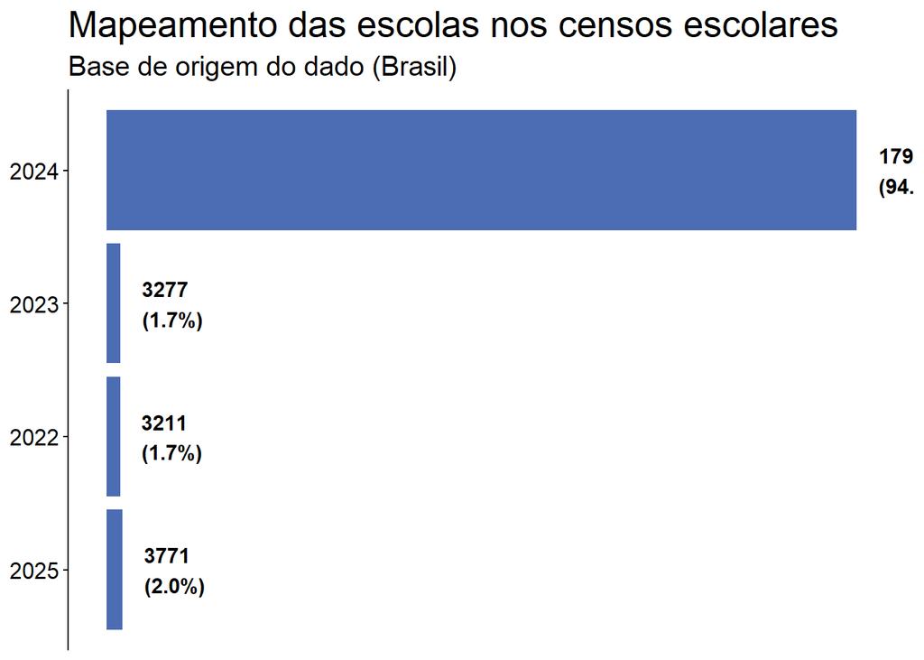

```r
base_unica_map_cnt_ano_orig |>
    mutate(
        label_val_abs_rel = str_c(tot_escolas, "\n(", prop, ")"),
        label_pos = tot_escolas + max(tot_escolas) * 0.025) |>
    ggplot(aes(x = fct_infreq(ano_cn_escolar), y = tot_escolas)) +
      geom_col(fill = "#4C6CB3") +
      geom_text(aes(y = label_pos, label = label_val_abs_rel),
                  hjust = -0.05,
                  size = 4,
                  fontface = "bold") +
      labs(
        title = "Mapeamento das escolas nos censos escolares",
        subtitle = ("Base de origem do dado (Brasil)"),
        x = NULL,
        y = NULL
        ) +
      coord_flip() +
      theme_classic() +
      theme(
        plot.title = element_text(size = 20),
        plot.subtitle = element_text(size = 15),
        axis.line.x = element_blank(),
        axis.ticks.x = element_blank(),
        axis.text.x = element_blank(),
        axis.title.x = element_blank(),
        axis.text.y = element_text(size = 12.5)
        )
```

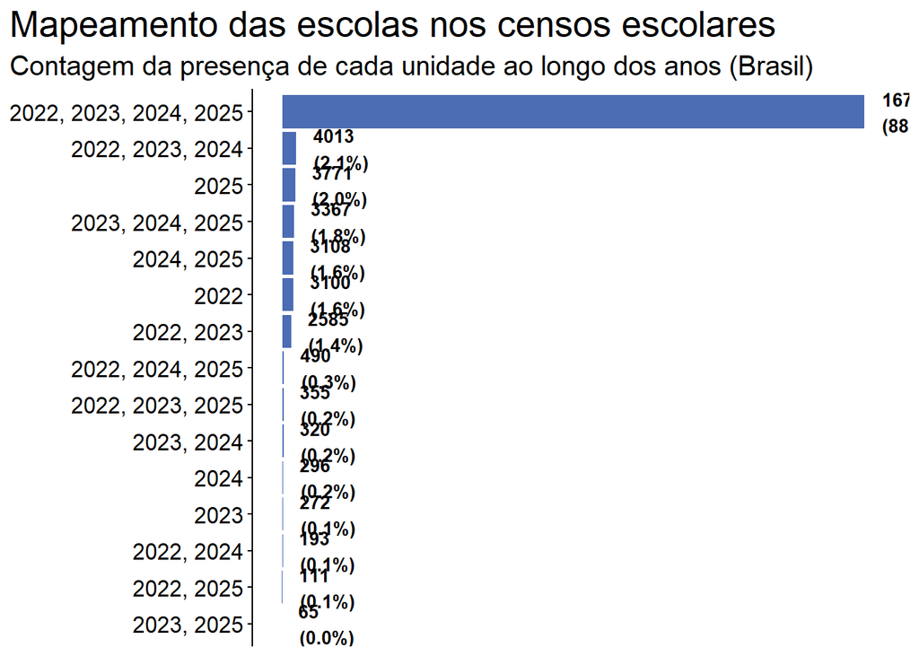

```r
# Gere um gráfico para representar a presença das escolas ao longo dos anos (Brasil)
base_unica_map_cnt_anos|>
  mutate(
    ano_censos_pres = fct_rev(fct_infreq(ano_censos_pres)),
    label_val_abs_rel = str_c(tot_escolas, "\n(", prop, ")"),
    label_pos = tot_escolas + max(tot_escolas) * 0.025) |>
      ggplot(aes(x = fct_reorder(ano_censos_pres, tot_escolas), y = tot_escolas)) +
        geom_col(fill = "#4C6CB3") +
        geom_text(aes(y = label_pos, label = label_val_abs_rel),
                  hjust = -0.05,
                  size = 3.5,
                  fontface = "bold") +
        labs(
          title = "Mapeamento das escolas nos censos escolares",
          subtitle = c("Contagem da presença de cada unidade ao longo dos anos (Brasil)"),
          x = NULL) +
        coord_flip() +
        theme_classic() +
        theme(
          plot.title = element_text(size = 20),
          plot.title.position = "plot",
          plot.subtitle = element_text(size = 15),
          axis.line.x = element_blank(),
          axis.ticks.x = element_blank(),
          axis.text.x = element_blank(),
          axis.title.x = element_blank(),
          axis.text.y = element_text(size = 12.5)
        )
```

A partir das tabelas, verifica-se que após a seleção de 2024 como ano referência, 94.6% (179286) dos dados das escolas são provenientes dessa base. Por sua vez, ao analisarmos a presença das escolas ao longo do tempo, nota-se que 88.4% (167499) estão presentes ao longo do período analisado, indicando uma estabilidade para o Brasil, como um todo.

Os dados por estado, por sua vez, podem ser vistos a seguir.

```r
# Crie uma tabela para representar a presença das escolas ao longo dos anos por ESTADOS
base_unica_map_cnt_anos_uf <- base_unica_map |>
  mutate(
    # tipo_censos_pres = factor(tipo_censos_pres , labels = c("Comum (3 bases)", "Compartilhado (2 bases)", "Exclusivo (1 base)")),
    ano_censos_pres =
        fct_relevel(ano_censos_pres, "2022, 2023, 2024, 2025", "2022, 2023, 2024", "2022, 2023, 2025", "2022, 2024, 2025", "2023, 2024, 2025", "2022, 2023", "2022, 2024", "2022, 2025", "2023, 2024", "2023, 2025", "2024, 2025", "2022", "2023",  "2024", "2025"  )) |>
  group_by(sg_uf, .drop = FALSE) |> # Caso queira realizar a leitura por município, acrescente a variável "nm_mun"
  count(ano_censos_pres, name = "tot_escolas") |>
  mutate(prop = scales::percent(tot_escolas/sum(tot_escolas), accuracy = 0.1))

base_unica_map_cnt_anos_uf |>
  janitor::adorn_totals() |>
  kable(col.names = c("Estado", "Ano do censo", "Total de escolas", "Proporção (%)"), align = 'clcc') # Caso o município tenha sido incluído no objeto anterior, ele tb deverá ser adicionado no parâmetro "col.names", entre as etiquetas "Estado" e "Ano do censo".
```

| Estado | Ano do censo | Total de escolas | Proporção (%) |
| --- | --- | --- | --- |
| AC | 2022, 2023, 2024, 2025 | 1428 | 89.0% |
| AC | 2022, 2023, 2024 | 32 | 2.0% |
| AC | 2022, 2023, 2025 | 8 | 0.5% |
| AC | 2022, 2024, 2025 | 4 | 0.2% |
| AC | 2023, 2024, 2025 | 25 | 1.6% |
| AC | 2022, 2023 | 19 | 1.2% |
| AC | 2022, 2024 | 0 | 0.0% |
| AC | 2022, 2025 | 4 | 0.2% |
| AC | 2023, 2024 | 2 | 0.1% |
| AC | 2023, 2025 | 2 | 0.1% |
| AC | 2024, 2025 | 22 | 1.4% |
| AC | 2022 | 28 | 1.7% |
| AC | 2023 | 0 | 0.0% |
| AC | 2024 | 3 | 0.2% |
| AC | 2025 | 28 | 1.7% |
| AL | 2022, 2023, 2024, 2025 | 2590 | 82.7% |
| AL | 2022, 2023, 2024 | 101 | 3.2% |
| AL | 2022, 2023, 2025 | 8 | 0.3% |
| AL | 2022, 2024, 2025 | 17 | 0.5% |
| AL | 2023, 2024, 2025 | 89 | 2.8% |
| AL | 2022, 2023 | 59 | 1.9% |
| AL | 2022, 2024 | 6 | 0.2% |
| AL | 2022, 2025 | 3 | 0.1% |
| AL | 2023, 2024 | 10 | 0.3% |
| AL | 2023, 2025 | 1 | 0.0% |
| AL | 2024, 2025 | 77 | 2.5% |
| AL | 2022 | 81 | 2.6% |
| AL | 2023 | 7 | 0.2% |
| AL | 2024 | 17 | 0.5% |
| AL | 2025 | 66 | 2.1% |

[output cut: 376 more lines]

[figure not shown]

```r
# Gere um gráfico para representar a presença das escolas ao longo dos anos por ESTADOS
base_unica_map_cnt_anos_uf |>
  mutate(
    lab_val_abs_rel = str_c(tot_escolas, " (", prop,")")
  ) |>
  ggplot(aes(x = fct_relevel(
    ano_censos_pres,
    c(
      str_c("2023", "2024", "2025", sep = ", "),
      str_c("2023", "2024", sep = ", "),
      str_c("2023", "2025", sep = ", "),
      str_c("2024", "2025", sep = ", "),
      "2023", "2024", "2025")), y = tot_escolas)) +
    geom_col(fill = "#4C6CB3") +
    geom_text(aes(label = lab_val_abs_rel),
              hjust = -0.1,
              size = 2.25,
              fontface = "bold") +
    labs(
      title = "Mapeamento das escolas nos censos escolares",
      subtitle = glue::glue("Contagem da presença de cada unidade escolar ao longo dos anos por unidade federativa ({paste(censo_esc_anos, collapse = ', ')})"),
      x = NULL) +
    coord_flip() +
    theme_classic() +
    theme(axis.line.x = element_blank(),
          axis.ticks.x = element_blank(),
          axis.text.x = element_blank(),
          axis.title.x = element_blank(),
          axis.text.y = element_text(size = 7),
          ) +
    facet_wrap(vars(sg_uf)) +
    scale_y_continuous(expand = expansion(mult = c(0.00, 0.2)))
```

Finalizada essa breve incursão exploratória, bem como a geração da base que será utilizada para a próxima etapa, a seguir passar-se-á à geocodificação.

## Geocodificação

### Acessando os dados do Catálogo de Escolas

Até o momento, os dados que permitem uma maior precisão para a localização das escolas referem-se às variáveis de *logradouro* e seus respectivos *números*. Contudo, nem sempre esses dados serão suficientes ou adequados, uma vez que para algumas escolas ou eles não existem ou indicam a localização de forma mais genérica (Estrada X, Terra Indígena, Área rural, etc.).

Para lidar com essa situação, uma nova base será explorada, o [Catálogo de Escolas](https://www.gov.br/inep/pt-br/acesso-a-informacao/dados-abertos/inep-data/catalogo-de-escolas).

#### Baixe o dado original (“Catálogo de Escolas”) com a localização das escolas

De forma complementar aos dados presentes nos microdados do [Censo Escolar](https://www.gov.br/inep/pt-br/areas-de-atuacao/pesquisas-estatisticas-e-indicadores/censo-escolar), outra fonte que será utilizada para o processo de geocodificação, como recém mencionado, é o [Catálogo de Escolas](https://anonymousdata.inep.gov.br/analytics/saw.dll?Portal&PortalPath=%2Fshared%2FCenso%20da%20Educa%C3%A7%C3%A3o%20B%C3%A1sica%2F_portal%2FCat%C3%A1logo%20de%20Escolas). Com os dados podendo ser acessados pelo site do [Inep Data](https://www.gov.br/inep/pt-br/acesso-a-informacao/dados-abertos/inep-data/catalogo-de-escolas), essa base permite acessar um par de coordenadas geográficas associado a cada uma das escolas.

**ImportantAtenção!**

**Essa etapa não é feita de forma automática**

Para baixar os dados, acesse a url do [Catálogo de Escolas](https://anonymousdata.inep.gov.br/analytics/saw.dll?Portal). Na página, **NÃO** selecione nenhuma variável e clique em “Aplicar”.

O site gerará um relatório detalhado, apresentando o seguinte texto (19/02/26):  
” Foram selecionadas 212.386 escolas. São apresentadas 25 escolas por página do relatório.  
Quando selecionada a opção exportar, o resultado detalhado com todas as entidades retornadas na busca constarão do arquivo eletrônico.”

Em seguida, pressione o botão “Exportar” para baixar o arquivo em csv:  
`Análise - Tabela da lista das escolas - Detalhado.csv`

Salve-o com o nome “catalogo_escolas” na pasta de dados originais criada no começo desse projeto.

#### Importe os dados originais do Catálogo de Escolas

A base do [Catálogo de Escolas](https://www.gov.br/inep/pt-br/acesso-a-informacao/dados-abertos/inep-data/catalogo-de-escolas) é formada por um conjunto de variáveis. Nem todas, porém, fornecem insumos para a geocodificação. Tendo isso em vista, o processo de importação a seguir seleciona apenas as variáveis que atendem a esse propósito.

```r
# Importe os dados do catálogo de escolas
catalogo_escolas <- read_csv(file.path(pasta_dados_originais,
  "catalogo_escolas.csv"),
  locale = locale(
  #   decimal_mark = ",",
  #   grouping_mark = ".",
    encoding = "UTF-8"),
  col_select = all_of(c("Escola", "Código INEP", "Endereço", "Latitude", "Longitude")),
  col_types = cols(
    # `Restrição de Atendimento` = col_character(),
    Escola = col_character(),
    `Código INEP` = col_character(),
    # UF = col_character(),
    # Município = col_character(),
    # Localização = col_character(),
    # `Localidade Diferenciada` = col_character(),
    # `Categoria Administrativa` = col_character(),
    Endereço = col_character(),
    # Telefone = col_character(),
    # `Dependência Administrativa` = col_character(),
    # `Categoria Escola Privada` = col_character(),
    # `Conveniada Poder Público` = col_character(),
    # `Regulamentação pelo Conselho de Educação` = col_character(),
    # `Porte da Escola` = col_character(),
    # `Etapas e Modalidade de Ensino Oferecidas` = col_character(),
    # `Outras Ofertas Educacionais` = col_character(),
    Latitude = col_number(),
    Longitude = col_number()
    # .default = col_factor()
  )) |>
  clean_names()
```

A partir da importação, é possível notar que o [Catálogo de Escolas](https://www.gov.br/inep/pt-br/acesso-a-informacao/dados-abertos/inep-data/catalogo-de-escolas) possui 212386 escolas cadastradas.

#### Analise a completude dos dados geográficos (para além dos NA)

Com a base do [Catálogo de Escolas](https://www.gov.br/inep/pt-br/acesso-a-informacao/dados-abertos/inep-data/catalogo-de-escolas) importada, passa-se a ter acesso a um novo dado: as coordenadas geográficas das escolas.

Para entender um pouco melhor esse dado e sua viabilidade de uso, a seguir duas informações são checadas: i) se o formato do dado está de acordo com o esperado e ii) a quantidade/o peso dos dados ausentes na base (completude).

```r
# Compute quais casos não seguem o padrão de escrita das coordenadas geográficas (excluindo-se os missing values)
catalogo_escolas |>
  summarise(
    # Cheque o padrão da latitude
    lat_invalidos = sum(
      !is.na(latitude) &
      !grepl("^-?\\d+[\\.,]\\d+$", latitude),
      na.rm = TRUE),
    # Cheque o padrão da longitude
    lon_invalidos = sum(
      !is.na(longitude) &
      !grepl("^-?\\d+[\\.,]\\d+$", longitude),
      na.rm = TRUE)) |>
    # Construa a tabela com os resultados
    knitr::kable(
      col.names = c("Latitude - valores sem o padrão esperado", "Longitude - valores sem o padrão esperado"),
      align = "c",
      caption = "Avaliando o padrão esperado dos valores de latitude e longitude")
```

Avaliando o padrão esperado dos valores de latitude e longitude

| Latitude - valores sem o padrão esperado | Longitude - valores sem o padrão esperado |
| --- | --- |
| 0 | 0 |

```r
# Compute o total e a proporção de escolas sem dados de latitude
tibble(# Total de NA
      tot_na = sum(is.na(catalogo_escolas$latitude)),
      # Proporção de NA
      prop_na = scales::percent(sum(is.na(catalogo_escolas$latitude)) / length(catalogo_escolas$latitude), accuracy = 0.1)) |>
      # Construção da tabela
      knitr::kable(
          col.names = c("Total de valores faltantes (NA)", "Proporção de valores faltantes (NA)"),
          align = "c",
          caption = "Avaliando os valores faltantes (NA) dos dados de latitude")
```

Avaliando os valores faltantes (NA) dos dados de latitude

| Total de valores faltantes (NA) | Proporção de valores faltantes (NA) |
| --- | --- |
| 54204 | 25.5% |

```r
# Compute o total e a proporção de escolas sem dados de longitude
tibble(# Total de NA
      tot_na = sum(is.na(catalogo_escolas$longitude)),
      # Proporção de NA
      prop_na = scales::percent(sum(is.na(catalogo_escolas$longitude)) / length(catalogo_escolas$longitude), accuracy = 0.1)) |>
      # Construção da tabela
      knitr::kable(
          col.names = c("Total de valores faltantes (NA)", "Proporção de valores faltantes (NA)"),
          align = "c",
          caption = "Avaliando os valores faltantes (NA) dos dados de longitude")
```

Avaliando os valores faltantes (NA) dos dados de longitude

| Total de valores faltantes (NA) | Proporção de valores faltantes (NA) |
| --- | --- |
| 54204 | 25.5% |

De acordo com os dados, a base parece ser uma fonte interessante para complementar os dados de localização obtidos por meio dos microdados do Censo Escolar.

#### Extração de dados de localização (caso da edição dos microdados do Censo Escolar de 2025)

Os campos de Logradouro, Número, CEP e Bairro foram removidos da base de microdados do Censo Escolar de 2025. Com isso, usaremos um script para extrair esses dados do campo Endereço da base do Catálogo de Endereços.

```r
# Dicionário de Vias (Base Correios)
# Listamos as versões completas (sem acento e com acento para garantir) e as abreviações
tipos_logradouro <- c(
  # Extensos
  "RUA", "AVENIDA", "TRAVESSA", "ALAMEDA", "RODOVIA", "PRACA", "PRAÇA",
  "ESTRADA", "VILA", "BECO", "CAMINHO", "QUADRA", "SETOR", "CONDOMINIO",
  "CONDOMÍNIO", "CHACARA", "CHÁCARA", "FAZENDA", "SITIO", "SÍTIO",
  "VIELA", "VIA", "VIADUTO", "LOTEAMENTO", "PASSARELA", "LARGO",
  "BOULEVARD", "MARGINAL", "RESIDENCIAL", "PARQUE", "TRECHO",
  "GALERIA", "MORRO", "BLOCO", "RAMAL", "PASSAGEM", "AEROPORTO",
  # Abreviados Comuns (o regex validará se eles possuem ponto ou não automaticamente)
  "AV", "TRAV", "TV", "AL", "ROD", "PC", "PÇA", "PÇ", "ESTR", "EST", "VL", "BC",
  "CAM", "QD", "ST", "COND", "CH", "FAZ", "SIT", "VD", "LOT", "LG", "BLV",
  "RES", "PQ", "TR", "GL", "PAS"
)

# Montagem inteligente da Regex
# Explicando a regra:
# 1. \b garante que pegue a palavra inteira (não vai pegar o "AV" dentro de "GAVETA")
# 2. paste(..., collapse = "|") junta todas as opções acima separadas por "ou" (|)
# 3. \.? no final significa que a palavra pode ou não ser seguida de um ponto final
# 4. Adicionamos explicitamente o \bR\. no final para tratar "R." (Rua abreviada) que é uma letra só.
padrao_via <- paste0("(?i)(\\b(", paste(tipos_logradouro, collapse = "|"), ")\\b\\.?|\\bR\\.)")

# 2. Algoritmo de Extração
catalogo_escolas <- catalogo_escolas |>
  mutate(
    # Extração do CEP: busca o padrão exato de 5 dígitos + hífen + 3 dígitos
    cep = str_extract(endereco, "\\d{5}-\\d{3}"),

    # Limpeza preparatória: remove o CEP, a cidade, e o estado (inclusive o ponto que vem antes do CEP)
    end_limpo = str_trim(str_remove(endereco, "(\\. )?\\d{5}-\\d{3}.*$")),

    # Quebra a string ao meio usando a última VÍRGULA como âncora

    # Separando pela ÚLTIMA vírgula
    # ".*(?=,)" captura tudo do início até a última vírgula que encontrar
    antes_virgula = case_when(
      str_detect(end_limpo, ",") ~ str_trim(str_extract(end_limpo, ".*(?=,)")),
      TRUE ~ end_limpo # Prevenção caso não haja vírgula
    ),

    depois_virgula = case_when(
      str_detect(end_limpo, ",") ~ str_trim(str_extract(end_limpo, "[^,]+$")),
      TRUE ~ end_limpo
    ),

    # Extração do Número: captura a primeira sequência sem espaços após a vírgula
    numero_bruto = str_extract(depois_virgula, "^[^\\s]+"),
    # Validação: mantém apenas se for estritamente numérico
    num_endereco = ifelse(str_detect(numero_bruto, "^\\d+$"), numero_bruto, NA_character_),

    # Extração da Localidade (Bairro):
    # Avalia os pontos APENAS na parte de trás da vírgula. Evita o falso positivo de "AV."
    nm_bairro = case_when(
      str_detect(depois_virgula, "\\.") ~ str_trim(str_extract(depois_virgula, "[^\\.]+$")),
      # Se não tem ponto depois da vírgula, o bairro é o texto que sobra após remover o número
      TRUE ~ str_trim(str_remove(depois_virgula, "^[^\\s]+\\s+"))
    ),

    # Extração do Logradouro:
    logradouro = case_when(
      # Trata exceções onde o logradouro real foi digitado DEPOIS da vírgula
      str_detect(depois_virgula, padrao_via) & !str_detect(antes_virgula, padrao_via) ~
        str_trim(str_extract(depois_virgula, paste0(padrao_via, ".*?(?=\\.|$)"))),

      # Se o logradouro estiver antes da vírgula, captura até o ponto final ou até o final da string
      TRUE ~ antes_virgula
    )
  ) |>

  # 3. Selecionar e ordenar apenas as colunas solicitadas
  select(codigo_inep, latitude, longitude, logradouro, num_endereco, cep, nm_bairro)
```

#### Renomeie, recodifique e selecione as variáveis de interesse (colunas)

Para facilitar a identificação e antecipar fontes eventuais de erros, a seguir as variáveis serão renomeadas e eventuais espaços na descrição das coordenadas geográficas eliminados.

```r
# Renomeie as variáveis e elimine os eventuais espaços do campo das coordenadas geográficas
catalogo_escolas_geo <- catalogo_escolas |>
  rename(
    # Renomeie as variáveis
    cod_escola = codigo_inep,
    lat_inep = latitude,
    long_inep = longitude,
    logradouro_ctlg = logradouro,
    num_endereco_ctlg = num_endereco,
    cep_ctlg = cep,
    nm_bairro_ctlg = nm_bairro
  ) |>
  mutate(
    # Remova os eventuais espaços extras das coord. geo.
    lat_inep = trimws(lat_inep),
    long_inep = trimws(long_inep)
  ) |>
  select(cod_escola, lat_inep, long_inep, logradouro_ctlg,
        num_endereco_ctlg, cep_ctlg, nm_bairro_ctlg)

glimpse(catalogo_escolas_geo)
```

```
Rows: 212,386
Columns: 7
$ cod_escola        <chr> "11000023", "11000040", "11000058", "11000082", "110…
$ lat_inep          <chr> "-8.758459", "-8.79373016", "-8.7607343", "-8.765205…
$ long_inep         <chr> "-63.8540109", "-63.88391863", "-63.9019859", "-63.8…
$ logradouro_ctlg   <chr> "AVENIDA AMAZONAS", "RUA CAETANO", "AVENIDA CARLOS G…
$ num_endereco_ctlg <chr> "6492", "3256", "1135", "1483", "1056", "605", NA, "…
$ cep_ctlg          <chr> "76824-556", "76808-108", "76801-123", "76804-214", …
$ nm_bairro_ctlg    <chr> "TIRADENTES", "CALADINHO", "CENTRO", "SANTA BARBARA"…
```

### Integrando as coordenadas geográficas (Catálogo de Escolas) à base única gerada anteriormente (microdados do Censo Escolar)

Com o acesso às coordenadas geográficas presentes no [Catálogo de Escolas](https://www.gov.br/inep/pt-br/acesso-a-informacao/dados-abertos/inep-data/catalogo-de-escolas) devidamente formatadas, a seguir será realizada a junção dessa base com a dos microdados gerada anteriormente (`base_unica_map`). Note, também, que uma nova coluna é criada (`fonte_coord_geo`). O objetivo é registrar a fonte original do dado.

```r
# Crie uma base única a partir dos microdados e Catálogo de Escolas
escolas_geo <- base_unica_map |>
  left_join(catalogo_escolas_geo, join_by("cod_escola")) |>
  mutate(fonte_coord_geo = case_when(
      !is.na(lat_inep) & !is.na(long_inep) ~ "catalogo_inep",
      TRUE ~ NA))

# Verifique a fonte dos dados presentes na base
escolas_geo |>
    count(fonte_coord_geo, name = "tot_escolas") |>
    knitr::kable(col.names = c("Fonte do dado", "Total de escolas"), align = 'lc')
```

| Fonte do dado | Total de escolas |
| --- | --- |
| catalogo_inep | 150374 |
| NA | 39171 |

Realizada a integração entre as bases (“microdados” e “catalogo_escolas”), verifica-se que boa parte das escolas possuem coordenadas geográficas (79.33). Ainda restam, contudo, 20.67% das escolas sem esse dado.

### Prepare a base para a geocodificação (escolas sem coordenadas geográficas)

Para lidar com a ausência de dados mais precisos sobre a dimensão espacial de algumas escolas, as coordenadas faltantes serão obtidas por meio do geocodebr, pacote disponibilizado pelo [IPEA](https://www.ipea.gov.br/portal/).

Dois objetos serão, então, criados: `escolas_com_coord_geo` e `escolas_sem_coord_geo`. Enquanto o primeiro registra os casos que já possuem coordenadas geográficas, o segundo armazenará as escolas que não possuem esses dados.

**ImportantAtenção!**

As coordenadas geradas via *geocodebr* são estimativas obtidas a partir das informações textuais de endereço. Nesse sentido, é importante frisar que a precisão espacial obtida está diretamente relacionada ao nível de detalhamento e qualidade dessa informação (logradouro, número, CEP, etc.). A depender do caso, ela pode variar da localização aproximada do imóvel ao centróide de áreas mais amplas, como as abrangidas pelo CEP ou município. Portanto, as coordenadas geográficas assim estimadas devem ser utilizadas com cautela, especialmente em análises espaciais de grande detalhamento.

```r
# Selecione as escolas com coordenadas geográficas
escolas_com_coord_geo <- escolas_geo |>
  filter(!is.na(lat_inep) & !is.na(long_inep))

# Selecione as escolas sem coordenadas geográficas
escolas_sem_coord_geo <- escolas_geo |>
  filter(is.na(lat_inep) | is.na(long_inep)) |>
  select(!c(lat_inep, long_inep))

# Para as escolas sem dados de endereço nos microdados (caso de 2025), atribua os dados do catálogo de escolas
escolas_com_coord_geo <- escolas_geo |>
  filter(!is.na(lat_inep) & !is.na(long_inep)) |>
  mutate(nm_bairro = ifelse(is.na(nm_bairro), nm_bairro_ctlg, nm_bairro),
         endereco = ifelse(is.na(endereco), logradouro_ctlg, endereco),
         num_endereco = ifelse(is.na(num_endereco), num_endereco_ctlg, num_endereco),
         cep = ifelse(is.na(cep), cep_ctlg, cep)) |>
  select(!c(logradouro_ctlg, num_endereco_ctlg, cep_ctlg, nm_bairro_ctlg))

escolas_sem_coord_geo <- escolas_sem_coord_geo |>
  mutate(nm_bairro = ifelse(is.na(nm_bairro), nm_bairro_ctlg, nm_bairro),
         endereco = ifelse(is.na(endereco), logradouro_ctlg, endereco),
         num_endereco = ifelse(is.na(num_endereco), num_endereco_ctlg, num_endereco),
         cep = ifelse(is.na(cep), cep_ctlg, cep)) |>
  select(!c(logradouro_ctlg, num_endereco_ctlg, cep_ctlg, nm_bairro_ctlg))
```

#### Geocodifique com o Geocodebr

Identificado o conjunto de escolas sem coordenadas geográficas, a seguir o procedimento de geocodificação será realizado. É importante lembrar, porém, que a base gerada até o momento contém dados de diferentes anos. Tal escolha, longe de ser fortuita, está relacionada à busca pela melhor localização possível das escolas.

Tendo esse objetivo em vista, propõe-se um procedimento de compatibilização entre os anos. A ideia consiste, basicamente, em geocodificar os endereços de todos os anos, compará-los e selecionar aqueles que apresentam os melhores resultados.

Nesse sentido, inicialmente criam-se objetos com i) os códigos das escolas sem coordenadas geográficas e ii) as variáveis que auxiliarão o algoritmo de geocodificação.

```r
# Selecione as variáveis que serão utilizadas na geocodificação
sel_var_geocod <- c("ano_cn_escolar", "cod_escola", "sg_uf", "cd_mun", "endereco", "num_endereco", "cep", "nm_bairro", "ano_censos_pres")

# Obtenha o código das escolas que não possuem coordenadas geográficas
sel_esc_sem_coordgeo <- escolas_sem_coord_geo |>
  pull(var = cod_escola)

# Veja o número de escolas selecionadas
length(sel_esc_sem_coordgeo)
```

```
[1] 39171
```

O próximo passo diz respeito à geração, de fato, das coordenadas geográficas para o conjunto de escolas que ainda não possui esses dados. Baseando-se no endereço registrado na base, um procedimento geral é proposto para implementar a geocodificação por ano (usa-se um *for loop* para isso).

#### Geocodifique com o Geocodebr

Feita a seleção das escolas sem coordenadas geográficas, o próximo passo consiste em obtê-las.

Para confirmar que o diretório temporário utilizado pelo pacote geocodebr está acessível e com permissão de escrita, execute o script abaixo.

```r
# 1. Verifica qual é o sistema operacional
is_windows <- .Platform$OS.type == "windows"

# 2. Define o caminho da pasta dependendo do sistema
if (is_windows) {
    # No Windows, usamos a pasta raiz do usuário para evitar bloqueios de administrador
    # e forçamos o uso de barras normais "/" para não confundir o DuckDB
    dir_base <- file.path(Sys.getenv("USERPROFILE"), "duckdb_cache")
    dir_duckdb <- normalizePath(dir_base, winslash = "/", mustWork = FALSE)

} else {
# No Linux/Mac (unix), o diretório temporário padrão do R não tem problemas de path
    dir_duckdb <- file.path(tempdir(), "duckdb_cache")
}

# 3. Cria a pasta com segurança (recursive = TRUE garante a criação de subpastas se necessário)
if (!dir.exists(dir_duckdb)) {
    dir.create(dir_duckdb, recursive = TRUE)
}

# 4. Aplica as variáveis de ambiente
Sys.setenv(DUCKDB_R_TEMP_DIRECTORY = dir_duckdb)
Sys.setenv(DUCKDB_EXTENSION_DIRECTORY = dir_duckdb)
```

O segundo passo diz respeito à geração de uma lista vazia (`resultados_geocod`). Funcionando como insumo para as próximas etapas, o objetivo dessa lista é armazenar os resultados que serão produzidos pela geocodificação para cada um dos anos.

Em seguida, passa-se à estruturação da base. Mais especificamente, serão selecionadas as escolas e as variáveis de interesse (salvos no objeto `base_esc_geocod_orig`).

Com a base estruturada, o algoritmo de geocodificação pode ser implementado. Para isso, inicialmente serão definidos os parâmetros requeridos pelo algoritmo (`campos`). Vencido esse passo, executa-se a função *geocode()* do pacote [Geocodebr](https://github.com/ipeaGIT/geocodebr). Note: de forma a explicitar uma exigência do algoritmo, o código a seguir inicia assegurando que todas as variáveis estão codificadas como `character`.

Finalizada a geocodificação, um novo conjunto de variáveis é gerado e acrescentado à base de entrada utilizada (`escolas_geocod`). De forma resumida, essas novas variáveis podem ser subdivididas em dois grupos: i) informações descritivas sobre a localização e ii) qualidade dos dados obtidos. Para o procedimento proposto, apenas algumas dessas variáveis serão retidas.

Por fim, o procedimento renomeia algumas variáveis (indicando o seu ano de origem) e salva os resultados na lista (inicialmente) vazia.

```r
# Lista vazia para armazenar os resultados de cada ano
resultados_geocod <- list()

for(ano in censo_esc_anos) {
  # Crie a base anual a ser geocodificada
  base_esc_geocod_orig <- base_unica_map_com_rep |>
    filter(cod_escola %in% sel_esc_sem_coordgeo & ano_cn_escolar == ano) |>
    select(-c("cep", "endereco", "num_endereco", "nm_bairro")) |>
    left_join(
      escolas_sem_coord_geo |>
        select("cod_escola", "nm_bairro", "endereco", "num_endereco", "cep"),
      by = "cod_escola"
    ) |>
    select(all_of(sel_var_geocod))

  # Defina os campos que serão utilizados para a geocodificação
  campos <- definir_campos(
    estado = "sg_uf",
    municipio = "cd_mun",
    logradouro = "endereco",
    numero = "num_endereco",
    cep = "cep",
    localidade = "nm_bairro")

  # Transforme a classe das variáveis (exigência do algoritmo)
  base_esc_geocod <- base_esc_geocod_orig |>
    mutate(across(everything(), as.character))

  # Realize a geocodificação
  escolas_geocod <- geocode(
    enderecos = base_esc_geocod,
    campos_endereco = campos,
    resultado_completo = TRUE,
    resultado_sf = FALSE,
    verboso = TRUE,
    cache = TRUE)

  # Selecione apenas as variáveis de interesse
  escolas_geocod <- escolas_geocod |>
    select(sg_uf, cd_mun, cod_escola, lat, lon, precisao, desvio_metros, tipo_resultado, ano_censos_pres)

  # Renomeie as colunas (exceto as variáveis que permanecerão as mesmas), acrescentando o ano
  ## Crie objetos auxiliares para identificar quais variáveis serão alteradas
  var_perm <- c("sg_uf", "cd_mun", "cod_escola")
  outras_var <- setdiff(names(escolas_geocod), var_perm)
  novos_nomes_var <- str_c(outras_var, "_", ano)

  ## Atribua os novos nomes as variáveis
  escolas_geocod <- escolas_geocod |>
    rename_with(
      ~ novos_nomes_var[which(outras_var == .x)],
      .cols = all_of(outras_var))

  # Guarde o resultado em uma lista
  resultados_geocod[[str_c("esc_geocod_", as.character(ano))]] <- escolas_geocod
}
```

[output not shown]

[output cut: 139 more lines]

[output not shown]

```r
# Veja os resultados
summary(resultados_geocod)
```

```
                Length Class      Mode
esc_geocod_2022 9      data.frame list
esc_geocod_2023 9      data.frame list
esc_geocod_2024 9      data.frame list
esc_geocod_2025 9      data.frame list
```

```r
str(resultados_geocod)
```

```
List of 4
 $ esc_geocod_2022:'data.frame':    29162 obs. of  9 variables:
  ..$ sg_uf               : chr [1:29162] "RO" "RO" "RO" "RO" ...
  ..$ cd_mun              : chr [1:29162] "1100205" "1100205" "1100205" "1100205" ...
  ..$ cod_escola          : chr [1:29162] "11000325" "11000546" "11000562" "11000635" ...
  ..$ lat_2022            : num [1:29162] -8.79 -9.78 -9.73 -9.11 -9.11 ...
  ..$ lon_2022            : num [1:29162] -63.9 -66.6 -65.5 -63.9 -63.9 ...
  ..$ precisao_2022       : chr [1:29162] "numero_aproximado" "cep" "cep" "cep" ...
  ..$ desvio_metros_2022  : int [1:29162] 6 14393 29046 120198 120198 17466 120198 6 120198 158686 ...
  ..$ tipo_resultado_2022 : chr [1:29162] "da03" "dc02" "dc01" "dc02" ...
  ..$ ano_censos_pres_2022: chr [1:29162] "2022, 2023" "2022" "2022, 2023, 2024, 2025" "2022, 2023, 2024, 2025" ...
 $ esc_geocod_2023:'data.frame':    30386 obs. of  9 variables:
  ..$ sg_uf               : chr [1:30386] "RO" "RO" "RO" "RO" ...
  ..$ cd_mun              : chr [1:30386] "1100205" "1100205" "1100205" "1100205" ...
  ..$ cod_escola          : chr [1:30386] "11000325" "11000562" "11000635" "11001011" ...
  ..$ lat_2023            : num [1:30386] -8.79 -9.73 -9.11 -9.11 -8.42 ...
  ..$ lon_2023            : num [1:30386] -63.9 -65.5 -63.9 -63.9 -63.5 ...
  ..$ precisao_2023       : chr [1:30386] "numero_aproximado" "cep" "cep" "cep" ...
  ..$ desvio_metros_2023  : int [1:30386] 6 29046 120198 120198 17466 120198 6 120198 158686 689 ...
  ..$ tipo_resultado_2023 : chr [1:30386] "da03" "dc01" "dc02" "dc02" ...
  ..$ ano_censos_pres_2023: chr [1:30386] "2022, 2023" "2022, 2023, 2024, 2025" "2022, 2023, 2024, 2025" "2022, 2023, 2024, 2025" ...
 $ esc_geocod_2024:'data.frame':    32105 obs. of  9 variables:
  ..$ sg_uf               : chr [1:32105] "RO" "RO" "RO" "RO" ...
  ..$ cd_mun              : chr [1:32105] "1100205" "1100205" "1100205" "1100205" ...
  ..$ cod_escola          : chr [1:32105] "11000562" "11000635" "11001011" "11001070" ...
  ..$ lat_2024            : num [1:32105] -9.73 -9.11 -9.11 -8.42 -9.11 ...
  ..$ lon_2024            : num [1:32105] -65.5 -63.9 -63.9 -63.5 -63.9 ...
  ..$ precisao_2024       : chr [1:32105] "cep" "cep" "cep" "cep" ...
  ..$ desvio_metros_2024  : int [1:32105] 29046 120198 120198 17466 120198 6 120198 158686 689 35351 ...
  ..$ tipo_resultado_2024 : chr [1:32105] "dc01" "dc02" "dc02" "dc02" ...
  ..$ ano_censos_pres_2024: chr [1:32105] "2022, 2023, 2024, 2025" "2022, 2023, 2024, 2025" "2022, 2023, 2024, 2025" "2022, 2023, 2024, 2025" ...
 $ esc_geocod_2025:'data.frame':    34289 obs. of  9 variables:
  ..$ sg_uf               : chr [1:34289] "RO" "RO" "RO" "RO" ...
  ..$ cd_mun              : chr [1:34289] "1100205" "1100205" "1100205" "1100205" ...
  ..$ cod_escola          : chr [1:34289] "11000562" "11000635" "11001011" "11001070" ...
  ..$ lat_2025            : num [1:34289] -9.73 -9.11 -9.11 -8.42 -9.11 ...
  ..$ lon_2025            : num [1:34289] -65.5 -63.9 -63.9 -63.5 -63.9 ...
  ..$ precisao_2025       : chr [1:34289] "cep" "cep" "cep" "cep" ...
  ..$ desvio_metros_2025  : int [1:34289] 29046 120198 120198 17466 120198 6 120198 158686 689 35351 ...
  ..$ tipo_resultado_2025 : chr [1:34289] "dc01" "dc02" "dc02" "dc02" ...
  ..$ ano_censos_pres_2025: chr [1:34289] "2022, 2023, 2024, 2025" "2022, 2023, 2024, 2025" "2022, 2023, 2024, 2025" "2022, 2023, 2024, 2025" ...
```

Antes dos comentários sobre a geocodificação, mencione-se que as mensagens de atenção (*warning messages*) geradas estão apenas alertando para a impossibilidade de converter alguns números para o formato *integer*, padrão de representação utilizado pelo algoritmo. Sempre que isso ocorre, o algoritmo substitui esse valor por um valor faltante (NA).

Isso posto, observa-se que a lista criada (`resultados_geocod`) apresenta os dados geocodificados para cada um dos 4 anos analisados. Essa forma de visualização, porém, é de difícil compreensão.

Diante deste fato e do resultado que se quer obter, a seguir a lista será transformada em uma única estrutura tabular (`escolas_geocod_tds_anos`). A partir dos sufixos das variáveis, que indicam o ano de origem do dado para cada uma das escolas, comparações serão mais facilmente realizáveis.

```r
# Transforme a lista com os resultados da geocodificação em uma única base tabular
escolas_geocod_tds_anos <- resultados_geocod |>
  reduce(full_join, by = c("sg_uf", "cd_mun", "cod_escola"))

# Veja os dados para as primeiras escolas da base única
escolas_geocod_tds_anos |>
  head() |>
  knitr::kable()
```

| sg_uf | cd_mun | cod_escola | lat_2022 | lon_2022 | precisao_2022 | desvio_metros_2022 | tipo_resultado_2022 | ano_censos_pres_2022 | lat_2023 | lon_2023 | precisao_2023 | desvio_metros_2023 | tipo_resultado_2023 | ano_censos_pres_2023 | lat_2024 | lon_2024 | precisao_2024 | desvio_metros_2024 | tipo_resultado_2024 | ano_censos_pres_2024 | lat_2025 | lon_2025 | precisao_2025 | desvio_metros_2025 | tipo_resultado_2025 | ano_censos_pres_2025 |
| --- | --- | --- | --- | --- | --- | --- | --- | --- | --- | --- | --- | --- | --- | --- | --- | --- | --- | --- | --- | --- | --- | --- | --- | --- | --- | --- |
| RO | 1100205 | 11000325 | -8.794654 | -63.88509 | numero_aproximado | 6 | da03 | 2022, 2023 | -8.794654 | -63.88509 | numero_aproximado | 6 | da03 | 2022, 2023 | NA | NA | NA | NA | NA | NA | NA | NA | NA | NA | NA | NA |
| RO | 1100205 | 11000546 | -9.775360 | -66.59998 | cep | 14393 | dc02 | 2022 | NA | NA | NA | NA | NA | NA | NA | NA | NA | NA | NA | NA | NA | NA | NA | NA | NA | NA |
| RO | 1100205 | 11000562 | -9.731319 | -65.53329 | cep | 29046 | dc01 | 2022, 2023, 2024, 2025 | -9.731319 | -65.53329 | cep | 29046 | dc01 | 2022, 2023, 2024, 2025 | -9.731319 | -65.53329 | cep | 29046 | dc01 | 2022, 2023, 2024, 2025 | -9.731319 | -65.53329 | cep | 29046 | dc01 | 2022, 2023, 2024, 2025 |
| RO | 1100205 | 11000635 | -9.111448 | -63.91765 | cep | 120198 | dc02 | 2022, 2023, 2024, 2025 | -9.111448 | -63.91765 | cep | 120198 | dc02 | 2022, 2023, 2024, 2025 | -9.111448 | -63.91765 | cep | 120198 | dc02 | 2022, 2023, 2024, 2025 | -9.111448 | -63.91765 | cep | 120198 | dc02 | 2022, 2023, 2024, 2025 |
| RO | 1100205 | 11001011 | -9.111448 | -63.91765 | cep | 120198 | dc02 | 2022, 2023, 2024, 2025 | -9.111448 | -63.91765 | cep | 120198 | dc02 | 2022, 2023, 2024, 2025 | -9.111448 | -63.91765 | cep | 120198 | dc02 | 2022, 2023, 2024, 2025 | -9.111448 | -63.91765 | cep | 120198 | dc02 | 2022, 2023, 2024, 2025 |
| RO | 1100205 | 11001070 | -8.418862 | -63.49341 | cep | 17466 | dc02 | 2022, 2023, 2024, 2025 | -8.418862 | -63.49341 | cep | 17466 | dc02 | 2022, 2023, 2024, 2025 | -8.418862 | -63.49341 | cep | 17466 | dc02 | 2022, 2023, 2024, 2025 | -8.418862 | -63.49341 | cep | 17466 | dc02 | 2022, 2023, 2024, 2025 |

A partir da geocodificação e da criação de uma base única para armazenar esses dados, é possível verificar que o procedimento gerou dados para 39208 escolas. Esse número, contudo, é ligeiramente maior do que a base de entrada (`escolas_sem_coord_geo`), que possui 39171 escolas. Isso ocorre, pois no processo de geocodificação ocorreu a duplicação de algumas escolas, expostas a seguir.

```r
# Crie um vetor para selecionar os casos duplicados
sel_esc_geocod_dupli <- duplicated(escolas_geocod_tds_anos$cod_escola)

# Quantifique os casos duplicados
sum(sel_esc_geocod_dupli)
```

```
[1] 37
```

```r
# Selecione e apresente os 10 casos aleatórios de escolas duplicadas
escolas_geocod_tds_anos |>
  filter(sel_esc_geocod_dupli) |>
  slice_sample(n = 10) |>
  kable()
```

[output not shown]

Uma vez que não deve haver duplicação na base das escolas geocodificadas, o próximo trecho eliminará esses casos. Em linhas gerais, a estratégia adotada consiste em:

- Agrupar as escolas a partir dos seus códigos de identificação - dessa forma, a duplicação será reconhecida;
- Identificar, para cada grupo de escolas, o menor desvio produzido no momento da geocodificação (o valor será salvo em uma variável auxiliar);
- Preencher as variáveis com valores faltantes a partir da comparação dos casos, e,
- Selecionar as escolas a partir dos menores valores de desvios existentes.

```r
escolas_geocod_tds_anos <- escolas_geocod_tds_anos |>
  # Agrupe os casos por código de escola
  group_by(cod_escola) |>

  # Identifique, em cada grupo, o menor desvio gerado pela geocodificação
  mutate(menor_desvio_da_linha = pmin(desvio_metros_2022,desvio_metros_2023, desvio_metros_2024, desvio_metros_2025, na.rm = TRUE)) |>

  # Compare, identifique os eventuais valores ausentes (NA) das variáveis da base e replique os valores para cima e para baixo dentro do mesmo código de escola
  fill(everything(), .direction = "downup") |>

  # Rearranje a base considerando o menor valor do desvio por código de escola
  arrange(menor_desvio_da_linha) |>

  # Remova a coluna auxiliar utilizada para identificar o menor desvio da geocodif.
  select(-menor_desvio_da_linha) |>

  # Selecione apenas a escola com o menor desvio global do mesmo código
  distinct(cod_escola, .keep_all = TRUE) |>

  # Desfaça os grupos criados
  ungroup()
```

Eliminada a duplicação de escolas da base geocodificada, a seguir apresentam-se: i) a estrutura da atual base e ii) a presença das escolas geocodificadas ao longo do tempo.

```r
# Veja a estrutura da base apenas com as escolas geocodificadas sem duplicação
glimpse(escolas_geocod_tds_anos)
```

```
Rows: 39,171
Columns: 27
$ sg_uf                <chr> "RO", "RO", "RO", "RO", "RO", "RO", "RO", "RO", "…
$ cd_mun               <chr> "1100205", "1100205", "1100106", "1100130", "1100…
$ cod_escola           <chr> "11000325", "11001267", "11006706", "11008598", "…
$ lat_2022             <dbl> -8.794654, -8.850409, -10.768905, -9.429623, -8.7…
$ lon_2022             <dbl> -63.88509, -63.94084, -65.33086, -62.00170, -63.9…
$ precisao_2022        <chr> "numero_aproximado", "numero_aproximado", "numero…
$ desvio_metros_2022   <int> 6, 6, 6, 6, 6, 6, 6, 6, 6, 6, 6, 6, 6, 6, 6, 6, 6…
$ tipo_resultado_2022  <chr> "da03", "pa01", "da01", "pa01", "dn01", "dn01", "…
$ ano_censos_pres_2022 <chr> "2022, 2023", "2022, 2023, 2024, 2025", "2022", "…
$ lat_2023             <dbl> -8.794654, -8.850409, NA, -9.429623, -8.751167, -…
$ lon_2023             <dbl> -63.88509, -63.94084, NA, -62.00170, -63.90322, -…
$ precisao_2023        <chr> "numero_aproximado", "numero_aproximado", NA, "nu…
$ desvio_metros_2023   <int> 6, 6, NA, 6, 6, 6, 6, 6, 6, 6, 6, 6, 6, 6, 6, 6, …
$ tipo_resultado_2023  <chr> "da03", "pa01", NA, "pa01", "dn01", "dn01", "dn01…
$ ano_censos_pres_2023 <chr> "2022, 2023", "2022, 2023, 2024, 2025", NA, "2022…
$ lat_2024             <dbl> NA, -8.850409, NA, -9.429623, -8.751167, -9.92009…
$ lon_2024             <dbl> NA, -63.94084, NA, -62.00170, -63.90322, -63.0171…
$ precisao_2024        <chr> NA, "numero_aproximado", NA, "numero_aproximado",…
$ desvio_metros_2024   <int> NA, 6, NA, 6, 6, 6, 6, 6, 6, 6, 6, 6, 6, 6, 6, 6,…
$ tipo_resultado_2024  <chr> NA, "pa01", NA, "pa01", "dn01", "dn01", "dn01", "…
$ ano_censos_pres_2024 <chr> NA, "2022, 2023, 2024, 2025", NA, "2022, 2023, 20…
$ lat_2025             <dbl> NA, -8.850409, NA, -9.429623, -8.751167, -9.92009…
$ lon_2025             <dbl> NA, -63.94084, NA, -62.00170, -63.90322, -63.0171…
$ precisao_2025        <chr> NA, "numero_aproximado", NA, "numero_aproximado",…
$ desvio_metros_2025   <int> NA, 6, NA, 6, 6, 6, 6, 6, 6, 6, 6, 6, 6, 6, 6, 6,…
$ tipo_resultado_2025  <chr> NA, "pa01", NA, "pa01", "dn01", "dn01", "dn01", "…
$ ano_censos_pres_2025 <chr> NA, "2022, 2023, 2024, 2025", NA, "2022, 2023, 20…
```

```r
# Identifique a presença das escolas geocodificados ao longo dos anos
escolas_geocod_tds_anos |>
  mutate(ano_censos_pres = case_when(
    is.na(ano_censos_pres_2025) & is.na(ano_censos_pres_2024) ~ ano_censos_pres_2023,
    is.na(ano_censos_pres_2025) & !is.na(ano_censos_pres_2024) ~ ano_censos_pres_2024,
    .default = ano_censos_pres_2025
  )) |>
  count(ano_censos_pres, sort = T, name = "tot_esc") |>
  mutate(prop = scales::percent(tot_esc/sum(tot_esc), accuracy = 0.1)) |>
  janitor::adorn_totals() |>
  knitr::kable(col.names = c("Presença nos censos (ano)", "Total de escolas", "Proporção (%)"), align = 'lcc')
```

| Presença nos censos (ano) | Total de escolas | Proporção (%) |
| --- | --- | --- |
| 2022, 2023, 2024, 2025 | 24520 | 62.6% |
| 2025 | 3657 | 9.3% |
| 2024, 2025 | 2938 | 7.5% |
| 2023, 2024, 2025 | 2627 | 6.7% |
| NA | 1556 | 4.0% |
| 2022, 2023 | 1279 | 3.3% |
| 2022, 2023, 2024 | 1215 | 3.1% |
| 2024 | 264 | 0.7% |
| 2023, 2024 | 237 | 0.6% |
| 2023 | 229 | 0.6% |
| 2022, 2023, 2025 | 222 | 0.6% |
| 2022, 2024, 2025 | 202 | 0.5% |
| 2022, 2024 | 102 | 0.3% |
| 2022, 2025 | 66 | 0.2% |
| 2023, 2025 | 57 | 0.1% |
| Total | 39171 | - |

Como demonstra a estrutura da base, com exceção das variáveis relacionadas à unidade federativa (`sg_uf`), ao código do município (`cd_mun`) e ao código de identificação único da escola (`cod_escola`), para todas as outras existem uma versão relacionada a cada ano do censo analisado (lat_2023, lon_2023, precisao_2023, etc.). No caso específico das coordenadas geográficas, deve-se ter apenas um par de referência - em tese, o de maior acurácia.

Nesse sentido, baseando-se no *menor valor de desvio da localização da escola* e na busca pelo *dado mais recente possível*, as próximas linhas do código selecionarão o caso (escola) com as melhores coordenadas. Apenas para exemplificar o exposto, se o desvio constatado para uma escola for de 6 metros, em 2023, e de 36 metros, em 2024, o par de coordenadas selecionado seria o do primeiro ano (2023). Por sua vez, se o desvio encontrado para ambos os anos for o mesmo, as coordenadas recuperadas estariam atreladas ao ano de 2024 (mais recente e adequado possível). Por fim, para fins de registro e análise, o histórico dos dados constará na base gerada.

```r
# Transforme as colunas anuais em formato longo
escolas_geocod_long <- escolas_geocod_tds_anos |>
  pivot_longer(
    cols = matches("^(precisao_|desvio_metros_|lat_|lon_)\\d{4}$"),
    # cols = matches("^(desvio_metros_)\\d{4}$"), # Esse linha não empilha as coord. geo.
    names_to = c(".value", "ano"),
    names_pattern = "^(.*)_(\\d{4})$") |>
      relocate(ends_with(as.character(censo_esc_anos)), .after = "desvio_metros")

# Selecione a escola com o menor desvio
escolas_geocod_melhor_ano <- escolas_geocod_long |>
  group_by(cod_escola, sg_uf, cd_mun) |>
  arrange(cod_escola, sg_uf, cd_mun, desvio_metros, desc(ano), .by_group = T) |>
  slice_head(n = 1) |>
  ungroup() |>
  rename(melhor_ano = ano,
         melhor_desvio = desvio_metros,
         melhor_latitude = lat,
         melhor_longitude = lon,
         melhor_precisao = precisao)

# Adicione todas as variáveis para análise histórica
escolas_geocod_compatib <- escolas_geocod_tds_anos |>
  left_join(escolas_geocod_melhor_ano) |>
  relocate(.after = cod_escola, starts_with("melhor"))
```

[output not shown]

A seguir, apresentam-se dois gráficos referentes à qualidade dos dados gerados, o primeiro para o Brasil, como um todo, e o segundo para as unidades federativas (estados).

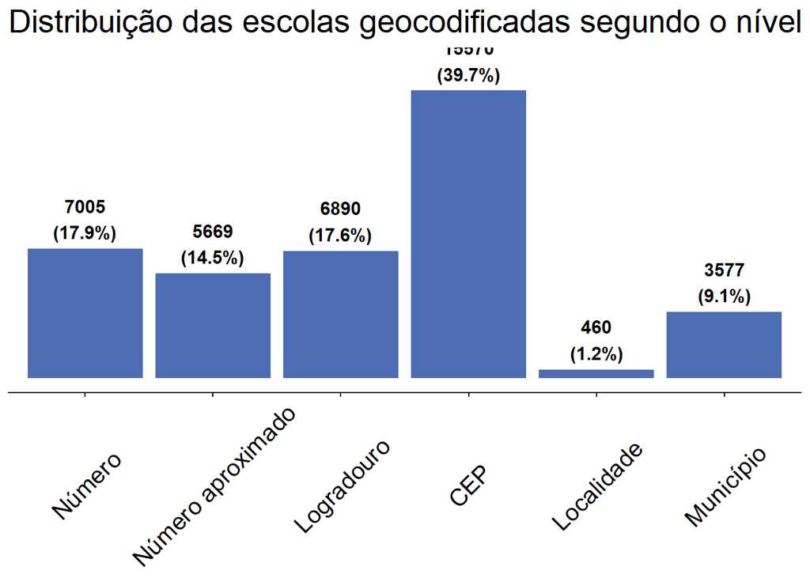

```r
# Crie um gráfico sobre a precisão das estimativas geradas durante a geocodificação (Brasil)
escolas_geocod_compatib |>
  summarize(n = n(), .by = melhor_precisao) |>
  mutate(
    prop = scales::percent((n / sum(n)), accuracy = 0.1),
    lab_val_abs_rel = str_c(n, "\n(", prop,")"),
    precisao = factor(
      melhor_precisao,
      levels = c("numero", "numero_aproximado", "logradouro", "cep", "localidade", "municipio"))) |>
  ggplot(aes(x = precisao, y = n, label = lab_val_abs_rel)) + # , label = (prop)
    geom_col(fill = "#4C6CB3") +
    geom_text(
      vjust = -0.25,
      size = 4,
      fontface = "bold") +
    scale_y_discrete(expand = expansion(mult = c(0.05, 0.15))) +
    scale_x_discrete(labels = c(
      "numero" = "Número",
      "numero_aproximado" = "Número aproximado",
      "logradouro" = "Logradouro",
      "cep" = "CEP",
      "localidade" = "Localidade",
      "municipio" = "Município")) +
    labs(
      title = "Distribuição das escolas geocodificadas segundo o nível de precisão (Brasil)",
      x = NULL,
      y = NULL) +
    theme_classic() +
    theme(
      axis.text.x = element_text(size = 15, angle = 45, vjust = 0.5),
      plot.title = element_text(size = 20),
      plot.title.position = "plot"
    )
```

[output not shown]

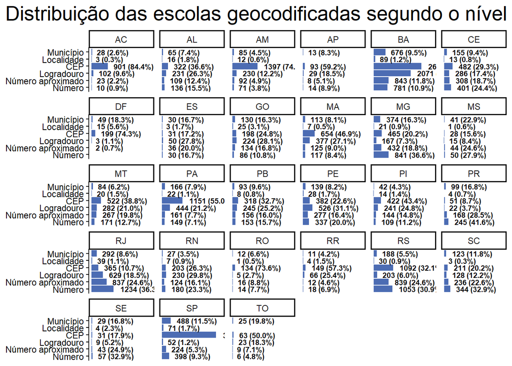

```r
# Crie um gráfico sobre a precisão das estimativas geradas durante a geocodificação (Estados - UF)
escolas_geocod_compatib |>
  group_by(sg_uf, melhor_precisao, .drop = FALSE) |>
  summarize(tot_escolas = n()) |> # , .by = melhor_precisao
  mutate(
    prop = scales::percent((tot_escolas / sum(tot_escolas)), accuracy = 0.1),
    lab_val_abs_rel = str_c(tot_escolas, " (", prop,")"),
    precisao = factor(
      melhor_precisao,
      levels = c("numero", "numero_aproximado", "logradouro", "cep", "localidade", "municipio"))
      ) |>
  drop_na() |>
  ggplot(aes(x = precisao, y = tot_escolas, label = lab_val_abs_rel)) + # , label = (prop)
    geom_col(fill = "#4C6CB3") +
    geom_text(
      hjust = -0.15,
      size = 2.5,
      fontface = "bold") +
    scale_y_discrete(expand = expansion(mult = c(0.05, 0.15))) +
    scale_x_discrete(labels = c(
      "numero" = "Número",
      "numero_aproximado" = "Número aproximado",
      "logradouro" = "Logradouro",
      "cep" = "CEP",
      "localidade" = "Localidade",
      "municipio" = "Município")) +
    labs(
      title = "Distribuição das escolas geocodificadas segundo o nível de precisão (Estados - UF)",
      x = NULL,
      y = NULL) +
    theme_classic() +
    theme(
      axis.text.x = element_text(size = 5),
      plot.title = element_text(size = 20),
      plot.title.position = "plot"
    ) +
    facet_wrap(vars(sg_uf)) +
    coord_flip()
```

#### Crie uma base única com as coordenadas geográficas geradas

Para a criação de uma base onde todas as escolas terão um par de coordenadas geográficas associado, a seguir serão selecionadas apenas algumas das variáveis da base proveniente da geocodificação.

```r
# Selecione o padrão de exclusão que será utilizado para excluir as colunas a seguir - neste caso, todas as variáveis que terminem com os seus respectivos anos
colunas_excluir <- "\\d{4}$"

# Exclua e adicione colunas de interesse e registre a fonte do dado
escolas_geocod_compatib <- escolas_geocod_compatib |>
  select(-any_of(matches(colunas_excluir))) |>
  mutate(fonte_coord_geo = "geocodebr")  |>
  left_join(base_unica_map_com_rep, join_by(sg_uf, cd_mun, cod_escola, melhor_ano == ano_cn_escolar))
```

O próximo passo consiste em integrar ambas as bases com coordenadas geográficas (`escolas_com_coord_geo` e `escolas_geocod_compatib`).

```r
# Junte as bases com coordenadas geográficas (originais e geocodificadas)
escolas_geo_tot <- escolas_com_coord_geo |>
  bind_rows(escolas_geocod_compatib)
```

Com a base única gerada (“escolas_geo_tot”), algumas transformações iniciais serão realizadas. Atreladas à organização das variáveis já existentes, as primeiras dizem respeito à criação de um campo único para armazenar as coordenadas geográficas - neste momento, verifica-se a existência das coordenadas geográficas provenientes do [Catálogo de Escolas](https://www.gov.br/inep/pt-br/acesso-a-informacao/dados-abertos/inep-data/catalogo-de-escolas) (“lat_inep” e “long_inep”) e as geradas pela geocodificação (“melhor_latitude” e “melhor_longitude”) - tratamento similar é realizado para o ano. Por sua vez, o outro grupo de modificações diz respeito ao ajuste da classe de algumas variáveis e a renomeação de algumas variáveis. Por fim, define-se um novo ordenamento para as variáveis e os casos.

```r
escolas_geo_tot <- escolas_geo_tot |>
  mutate(
    # Junte as informações das coordenadas geográficas nos mesmos campos
    lat = if_else(!is.na(lat_inep), as.numeric(lat_inep), melhor_latitude),
    lon = if_else(!is.na(long_inep), as.numeric(long_inep), melhor_longitude),
    fonte_ano_cn_escolar = if_else(!is.na(melhor_ano), melhor_ano, ano_cn_escolar)
  ) |>
  select(!c(lat_inep, long_inep, melhor_ano, melhor_latitude, melhor_longitude, ano_cn_escolar)) |>
  # drop_na(c(lat, lon)) |>
  rename(
    precisao = melhor_precisao,
    desvio_metros = melhor_desvio
    ) |>
  relocate(cod_escola, nm_escola, lat, lon, precisao, desvio_metros, fonte_coord_geo, fonte_ano_cn_escolar, tp_dependencia, qt_mat_bas, sg_uf, cd_mun, cep, endereco, num_endereco, nm_bairro) |>
  arrange(cod_escola)

escolas_geo_tot |>
  glimpse()
```

```
Rows: 189,545
Columns: 20
$ cod_escola           <chr> "11000023", "11000040", "11000058", "11000082", "…
$ nm_escola            <chr> "EEEE ABNAEL MACHADO DE LIMA - CENE", "EMEIEF PEQ…
$ lat                  <dbl> -8.758459, -8.793730, -8.760734, -8.765205, -8.76…
$ lon                  <dbl> -63.85401, -63.88392, -63.90199, -63.89618, -63.8…
$ precisao             <chr> NA, NA, NA, NA, NA, NA, NA, NA, NA, NA, NA, NA, N…
$ desvio_metros        <int> NA, NA, NA, NA, NA, NA, NA, NA, NA, NA, NA, NA, N…
$ fonte_coord_geo      <chr> "catalogo_inep", "catalogo_inep", "catalogo_inep"…
$ fonte_ano_cn_escolar <chr> "2024", "2024", "2024", "2024", "2024", "2022", "…
$ tp_dependencia       <chr> "Estadual", "Municipal", "Privada", "Privada", "P…
$ qt_mat_bas           <chr> "71", "207", "1135", "58", "556", "175", "1046", …
$ sg_uf                <chr> "RO", "RO", "RO", "RO", "RO", "RO", "RO", "RO", "…
$ cd_mun               <chr> "1100205", "1100205", "1100205", "1100205", "1100…
$ cep                  <chr> "76824556", "76808108", "76801123", "76804214", "…
$ endereco             <chr> "AVENIDA AMAZONAS", "RUA CAETANO", "AVENIDA CARLO…
$ num_endereco         <chr> "6492", "3256", "1135", "1483", "1056", "605", "4…
$ nm_bairro            <chr> "TIRADENTES", "CALADINHO", "CENTRO", "SANTA BARBA…
$ nm_mun               <chr> "Porto Velho", "Porto Velho", "Porto Velho", "Por…
$ no_censos_pres       <int> 4, 4, 4, 3, 4, 1, 4, 4, 4, 4, 4, 4, 4, 2, 4, 4, 4…
$ ano_censos_pres      <chr> "2022, 2023, 2024, 2025", "2022, 2023, 2024, 2025…
$ tipo_censos_pres     <chr> "4_bases", "4_bases", "4_bases", "3_bases", "4_ba…
```

Realizados esses primeiros ajustes, uma nova forma de registrar a presença das escolas ao longo do tempo é feita. Para isso, são criadas variáveis específicas para cada um dos anos dos censos analisados. Essas variáveis, por sua vez, indicarão a presença (“TRUE”) ou ausência (FALSE) da escola naquele ano.

```r
escolas_geo_tot <- escolas_geo_tot |>
    mutate(
        pres_ano_22 = str_detect(ano_censos_pres, pattern = "2022"),
        pres_ano_23 = str_detect(ano_censos_pres, pattern = "2023"),
        pres_ano_24 = str_detect(ano_censos_pres, pattern = "2024"),
        pres_ano_25 = str_detect(ano_censos_pres, pattern = "2025")
    )
```

Com a base organizada, é possível ver, por exemplo, o resultado final a partir da fonte original/produtora do dado espacial.

```r
# Visualize a fonte dos dados geográficos na base única gerada
escolas_geo_tot |>
  count(fonte_coord_geo, name = "tot_escolas") |>
  mutate(prop = tot_escolas / sum(tot_escolas)) |>
  arrange(desc("tot_escolas")) |>
  mutate(prop = scales::percent(prop, accuracy = 0.1)) |>
  knitr::kable(
    digits = 1,
    col.names = c("Fonte do dado geográfico", "No. de escolas", "Proporção (%)"),
    caption = "Origem dos dados geográficos associados às escolas",
    align = "lcc",
    format.args = list(big.mark = ".", decimal.mark = ","))
```

Origem dos dados geográficos associados às escolas

| Fonte do dado geográfico | No. de escolas | Proporção (%) |
| --- | --- | --- |
| catalogo_inep | 150.374 | 79.3% |
| geocodebr | 39.171 | 20.7% |

## Exportação dos dados

### Salvando a base final sem o formato espacial

Após a união/junção e organização dos dados do [Censo Escolar](https://www.gov.br/inep/pt-br/areas-de-atuacao/pesquisas-estatisticas-e-indicadores/censo-escolar) e do [Catálogo de Escolas](https://www.gov.br/inep/pt-br/acesso-a-informacao/dados-abertos/inep-data/catalogo-de-escolas), uma primeira versão da base única já pode ser exportada em três formatos distintos: “csv”, “parquet” e “rds”.

```r
# Exporte a base gerada no formato .csv
write_csv(escolas_geo_tot, file.path(pasta_dados_processados, str_c("escolas_geo_hist.csv")))

# Exporte a base gerada no formato .parquet
# write_parquet(escolas_geo_tot, file.path(pasta_dados_processados, str_c("escolas_geo_hist.parquet")))

# Exporte a base no formato .rds, nativo do R.
saveRDS(
  escolas_geo_tot,
  file.path(pasta_dados_processados, str_c("escolas_geo_hist.rds")))
```

Note que, ainda que apresente as coordenadas geográficas para todas as escolas, a base recém-exportada não é um objeto espacial. Para isso, ela precisa ser transformada, como será feito a seguir.

```r
# Transforme a base em um objeto espacial do tipo "sf"
escolas_tot_geo <- st_as_sf(
  escolas_geo_tot |> drop_na(c(lon, lat)),
  coords = c("lon", "lat"),
  crs = 4674) # SIRGAS 2000

# Cheque se a classe do objeto foi realizada
class(escolas_tot_geo)

# Visualize rapidamente se a transformação ocorreu como esperado (os pontos deveriam formar uma ideia dos limites do Brasil)
plot(escolas_tot_geo["cod_escola"], main = "Distribuição das escolas brasileiras (2022 a 2025)")
```

[output not shown]

Criado o objeto espacial, os dados serão exportados como geopackage, um formato de dados geoespacial aberto.

```r
# Exporte o objeto espacial criado como geopackage
st_write(
  escolas_tot_geo,
  dsn = file.path(
    pasta_dados_processados,
    str_c("escolas_geo_hist.gpkg")),
  append = FALSE)

# Exporte o objeto espacial criado como .parquet
st_write_parquet(escolas_tot_geo, dsn = file.path(pasta_dados_processados, str_c("escolas_geo_hist.parquet")))
```